# Limpieza y transformación de los datos

En este notebook tutorial aprenderás a corregir errores e inconsistencias en el conjunto de datos, explorando distintas estrategias para hacerlo. Además, aprenderás a aplicar diversas técnicas de transformación de datos con el fin de mejorar su utilidad y facilitar su análisis por los algoritmos de aprendizaje.

Este notebook estará compuesto de las siguientes partes:

1. Importar las librerías que usaremos.
2. Cargar el conjunto de datos.
3. Limpieza de datos.
4. Transformación de datos.

El conjunto de datos que usaremos a lo largo de este notebook recopila información sobre la venta de inmuebles, la cual incluye variables que describen las características principales de cada uno y el precio final de venta. El análisis de estos datos puede ser útil para comprender los factores que influyen en el valor de mercado de los inmuebles y para construir modelos predictivos para este sector.

## 1. Importar las librerías que usaremos

En este notebook usaremos las librerías de Pandas y Scikit-Learn, así como Matplotlib y Seaborn. Veamos la funcionalidad de cada una:

- **Pandas**: nos permite cargar, explorar y manipular grandes conjuntos de datos.
- **Scikit-Learn**: brinda herramientas para tareas como clasificación, regresión, agrupamiento, entre otras. También permite hacer tareas de transformación para adecuar los datos a los modelos.
- **Matplotlib**: nos ayuda a crear visualizaciones y gráficos personalizados.
- **Seaborn**: facilita la creación de gráficos estadísticos.

```python
import pandas as pd
import matplotlib.pyplot as plt
import seaborn as sns

from sklearn.preprocessing import MinMaxScaler
from sklearn.preprocessing import OrdinalEncoder, OneHotEncoder
```

Podemos revisar las versiones de las librerías a usar. Esto es útil para asegurar la compatibilidad del código y reproducibilidad de resultados en otros entornos, localmente o en Google Colab, evitando errores inesperados. Además, sirve para revisar la documentación adeduada porque puede cambiar con el tiempo.

```python
from importlib.metadata import version
print(f"Versión de Pandas: {version('pandas')}")
print(f"Versión de Matplotlib: {version('matplotlib')}")
print(f"Versión de Seaborn: {version('seaborn')}")
print(f"Versión de Scikit learn: {version('scikit-learn')}")
```

```
Versión de Pandas: 3.0.0
Versión de Matplotlib: 3.10.8
Versión de Seaborn: 0.13.2
Versión de Scikit learn: 1.8.0
```

## 2. Cargar un conjunto de datos

En esta parte, al igual que en el notebook pasado, procederemos a importar los datos que vamos a usar en este tutorial. Este archivo se encuentra en formato Excel. Para leerlo usaremos la función de Pandas `read_excel()`. En este caso, nuevamente almacenaremos el archivo Excel en el subdirectorio `data`, que se encuentra en el mismo directorio de este notebook. Si el conjunto tiene una ubicación diferente, puedes cambiar la ruta al interior de los paréntesis o modificar la ubicación del archivo.

En caso de que el conjunto de datos se encuentre en formato CSV, usaremos la función `read_csv()`.

```python
datos_inmuebles = pd.read_excel('./data/Venta_Inmuebles.xlsx')
```

Con esta sentencia, el archivo Excel se transforma en un DataFrame, una estructura compuesta de filas y columnas. La librería de Pandas, nos ayuda a estructurar los datos de esta forma para facilitar su exploración, manipulación y análisis de los datos.

Una buena práctica es trabajar siempre con una copia de los datos:

```python
data = datos_inmuebles.copy()
```

## 3. Limpieza

En el notebook #1 (Manipulación, Exploración y Calidad) identificamos distintos problemas de calidad en los datos en los aspectos:

- Completitud.
- Unicidad.
- Consistencia.
- Validez.

### Completitud

Esta dimensión mide el grado en que los datos contienen la información esperada, es decir, que no presenten valores faltantes.

```python
((data.isnull().sum()/data.shape[0])).sort_values(ascending=False)
```

```
Calificación       0.000278
Fecha              0.000000
Precio             0.000000
Cuartos            0.000000
Id                 0.000000
Baños              0.000000
AreaHabitable      0.000000
Pisos              0.000000
AreaLote           0.000000
FrenteMar          0.000000
Vista              0.000000
Condición          0.000000
AreaSuperior       0.000000
AreaBase           0.000000
Años               0.000000
Renovación         0.000000
CodigoPostal       0.000000
Latitud            0.000000
Longitud           0.000000
AreaHabitable15    0.000000
AreaLote15         0.000000
dtype: float64
```

Vemos que la única variable (columna) que tiene datos faltantes es `Calificación`, por lo que tenemos que tomar decisiones para poder cumplir con la Completitud y que nuestro DataFrame cumpla con los supuestos de calidad.

Exploremos un poco más y veamos los registros con valores nulos.

```python
# Filtrar filas con Calificación nula
nulos = data[data['Calificación'].isna()].copy()

# Contar cuántas son
print(f"Filas con Calificación nula: {nulos.shape[0]}")

# Guardar los índices
indices = data.index[data['Calificación'].isna()]

# Mostrar tabla
nulos
```

```
Filas con Calificación nula: 6
```

|  | Id | Fecha | Precio | Cuartos | Baños | AreaHabitable | AreaLote | Pisos | FrenteMar | Vista | ... | Calificación | AreaSuperior | AreaBase | Años | Renovación | CodigoPostal | Latitud | Longitud | AreaHabitable15 | AreaLote15 |
| --- | --- | --- | --- | --- | --- | --- | --- | --- | --- | --- | --- | --- | --- | --- | --- | --- | --- | --- | --- | --- | --- |
| 129 | 7853210060 | 20150406T000000 | 430000.0 | 4 | 2.50 | 2070 | 4310 | 2.0 | NO | 0 | ... | NaN | 2070 | 0 | 2004 | 0 | 98065 | 475319.0 | -121.85 | 1970 | 3748 |
| 130 | 3668000070 | 20150105T000000 | 212000.0 | 3 | 1.75 | 1060 | 7875 | 1.0 | NO | 0 | ... | NaN | 1060 | 0 | 1986 | 0 | 98092 | 472761.0 | -122152.00 | 1420 | 7680 |
| 231 | 2424000060 | 20140616T000000 | 500000.0 | 4 | 2.75 | 2280 | 15347 | 1.0 | NO | 0 | ... | NaN | 2280 | 0 | 1960 | 0 | 98059 | 475218.0 | -122164.00 | 2280 | 15347 |
| 234 | 3677400445 | 20140902T000000 | 475000.0 | 3 | 1.50 | 2480 | 5280 | 1.5 | NO | 0 | ... | NaN | 1620 | 860 | 1947 | 0 | 98108 | 475575.0 | -122303.00 | 2090 | 4800 |
| 4411 | 2470100110 | 20140804T000000 | 5570000.0 | 5 | 5.75 | 9200 | 35069 | 2.0 | NO | 0 | ... | NaN | 6200 | 3000 | 2001 | 0 | 98039 | 476289.0 | -122233.00 | 3560 | 24345 |
| 7907 | 1068000375 | 20140923T000000 | 3200000.0 | 6 | 5.00 | 7100 | 18200 | 2.5 | NO | 0 | ... | NaN | 5240 | 1860 | 1933 | 2002 | 98199 | 476427.0 | -122408.00 | 3130 | 6477 |

6 rows × 21 columns

Para solucionar este problema tenemos distintas alternativas:

1. **Eliminación de registros**: Se eliminan las filas que contienen valores ausentes en la columna afectada, esta opción es la más rápida, pero es importante saber cuándo usarla. La eliminación de filas se da cuando el porcentaje ausencias es muy bajo, por lo que eliminar esas filas no afectaría de forma significativa el análisis. Aunque es sencilla de implementar, pero nos lleva a la perdida de información, lo cual es algo que generalmente no queremos.
2. **Imputación con un valor de tendencia central**: En este caso se reemplazan los valores ausentes con una medida estadística como lo podrían ser la media, mediana o moda. Lo que se busca con esta estrategia es conservar todos los registros, aprovechando que el valor imputado no distorsionará la distribución observada de la variable.
3. **Imputación proporcional basada en otra variable**: Esta solución busca estimar los valores faltantes usando una relación proporcional con otra variable del DataFrame. Esta alternativa se usa cuando se observa una relación fuerte y consistente entre la variable con valores nulos y otra, también cuando se busca una imputación más contextualizada que la media o mediana, buscando reducir el sesgo que una imputación simple puede representar.

Para solucionar el problema de completitud de nuestro dataset exploraremos la tercera estrategía. Para esto tenemos que encontrar una variable que sea directamente proporcional y de esa relación extraer los datos faltantes.

El reto está en saber cual es el que reduce el sesgo y permite asignar los valores más reales.

Primero vamos a ver si nuestra variable de interés `Calificación` está relacionada directamente con otra para pensar en posibles relaciones. Para ello usamos el Heatmap que exploramos anteriormente:

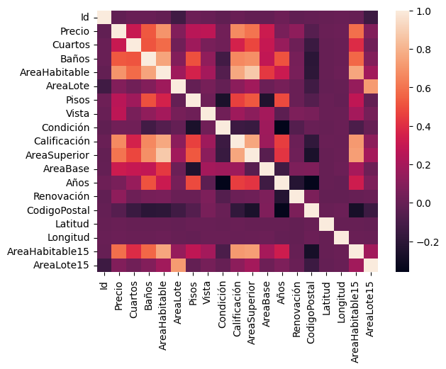

```python
sns.heatmap(data.corr(numeric_only=True))
```

Como vemos en el Heatmap, de acuerdo a la paleta del lado derecho, las variables que se relacionan en proporción cercana a 1.0 son las que tienen un color más claro. Allí vemos que son tres las variables que muestran esa relación: `AreaHabitable`, `AreaSuperior` y `AreaHabitable15`. Es allí en donde podemos ahondar para encontrar una solución a este problema.

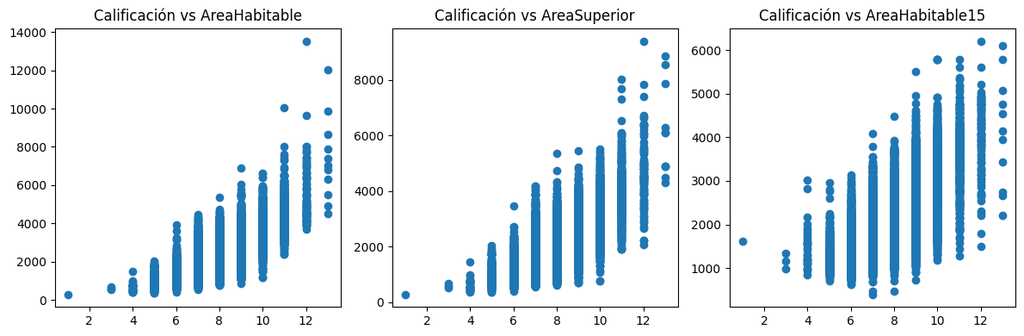

```python
fig, ax = plt.subplots(1, 3, figsize=(12, 4))

ax[0].scatter(data['Calificación'], data['AreaHabitable']); ax[0].set_title('Calificación vs AreaHabitable')
ax[1].scatter(data['Calificación'], data['AreaSuperior']); ax[1].set_title('Calificación vs AreaSuperior')
ax[2].scatter(data['Calificación'], data['AreaHabitable15']); ax[2].set_title('Calificación vs AreaHabitable15')

plt.tight_layout()
plt.show()
```

Vemos que en estas tres gráficas, se tiene una relación directamente proporcional entre las variables estudiadas y `Calificación`. Con el objetivo de asignar los valores faltantes, vamos a encontrar la relación entre esta variable y `AreaHabitable`, la cual teniendo en cuenta lo visto en la gráfica presenta una nube de puntos que sube de forma monótona y casi lineal a lo largo de todo el eje X.

```python
# Calcula k
k = (data['Calificación'] / data['AreaHabitable']).dropna().median()

# Imputa valores faltantes
data= data.fillna({'Calificación': k * data['AreaHabitable']})
# Alternativa: data.loc[data['Calificación'].isna(), 'Calificación'] = k * data['AreaHabitable']


# Redonde al entero más cercano
data['Calificación'] = data['Calificación'].round()

# Aplica límites según el diccionario
data['Calificación'] = data['Calificación'].clip(lower=1, upper=13)
# Alternativa: data[(data['Calificación'] >= 1) & (data['Calificación'] <= 13)]
```

Usando esa proporción calculamos los valores faltantes para la columna `Calificación`. Adicionalmente, lo redondeamos al entero más cercano para que este dato sea igual a los demás, ya que todos son enteros. Y por último, aplicamos los mismo límites que tiene el diccionario, ya que algunas veces al hacer el cálculo con la proporción se pueden tener valores fuera del rango.

```python
data.loc[indices]
```

|  | Id | Fecha | Precio | Cuartos | Baños | AreaHabitable | AreaLote | Pisos | FrenteMar | Vista | ... | Calificación | AreaSuperior | AreaBase | Años | Renovación | CodigoPostal | Latitud | Longitud | AreaHabitable15 | AreaLote15 |
| --- | --- | --- | --- | --- | --- | --- | --- | --- | --- | --- | --- | --- | --- | --- | --- | --- | --- | --- | --- | --- | --- |
| 129 | 7853210060 | 20150406T000000 | 430000.0 | 4 | 2.50 | 2070 | 4310 | 2.0 | NO | 0 | ... | 8.0 | 2070 | 0 | 2004 | 0 | 98065 | 475319.0 | -121.85 | 1970 | 3748 |
| 130 | 3668000070 | 20150105T000000 | 212000.0 | 3 | 1.75 | 1060 | 7875 | 1.0 | NO | 0 | ... | 4.0 | 1060 | 0 | 1986 | 0 | 98092 | 472761.0 | -122152.00 | 1420 | 7680 |
| 231 | 2424000060 | 20140616T000000 | 500000.0 | 4 | 2.75 | 2280 | 15347 | 1.0 | NO | 0 | ... | 9.0 | 2280 | 0 | 1960 | 0 | 98059 | 475218.0 | -122164.00 | 2280 | 15347 |
| 234 | 3677400445 | 20140902T000000 | 475000.0 | 3 | 1.50 | 2480 | 5280 | 1.5 | NO | 0 | ... | 10.0 | 1620 | 860 | 1947 | 0 | 98108 | 475575.0 | -122303.00 | 2090 | 4800 |
| 4411 | 2470100110 | 20140804T000000 | 5570000.0 | 5 | 5.75 | 9200 | 35069 | 2.0 | NO | 0 | ... | 13.0 | 6200 | 3000 | 2001 | 0 | 98039 | 476289.0 | -122233.00 | 3560 | 24345 |
| 7907 | 1068000375 | 20140923T000000 | 3200000.0 | 6 | 5.00 | 7100 | 18200 | 2.5 | NO | 0 | ... | 13.0 | 5240 | 1860 | 1933 | 2002 | 98199 | 476427.0 | -122408.00 | 3130 | 6477 |

6 rows × 21 columns

Veamos si algún se tiene algún otro campo como nulo:

```python
((data.isnull().sum()/data.shape[0])).sort_values(ascending=False)
```

```
Id                 0.0
Fecha              0.0
Precio             0.0
Cuartos            0.0
Baños              0.0
AreaHabitable      0.0
AreaLote           0.0
Pisos              0.0
FrenteMar          0.0
Vista              0.0
Condición          0.0
Calificación       0.0
AreaSuperior       0.0
AreaBase           0.0
Años               0.0
Renovación         0.0
CodigoPostal       0.0
Latitud            0.0
Longitud           0.0
AreaHabitable15    0.0
AreaLote15         0.0
dtype: float64
```

Esto significa que ya corregimos el error de Completitud.

#### Ejercicio

Implementa las otras dos alternativas para la solución de Completitud: elimina las filas que contienen los valores nulos de la columna `Calificación` y utiliza una imputación por la moda. Para esto, revisa la funcionalidad de scikit-learn ["SimpleImputer"](https://scikit-learn.org/stable/modules/generated/sklearn.impute.SimpleImputer.html#sklearn.impute.SimpleImputer).

Para los ejercicios usa los datos originales con una variable `dataprueba`, para no alterar el dataset `data` que es el que hemos venido manipulando.

```python
# Solución alternativa de completitud 1, con dataprueba1
```

```python
# Solución alternativa de completitud 2, con dataprueba2
```

### Unicidad

Indica que cada registro aparece una única vez en el DataFrame, es decir, que no existen registros duplicados.

```python
data.duplicated(keep = False).sum()
```

```
np.int64(0)
```

Podemos ver que no existen registros duplicados. Pero, podemos ir más allá, y ver si hay más de un registro con el mismo id, el cual debería ser único para cada dato:

#### Manera 1

```python
# ids duplicados
dup_counts = (data[["Id","Precio"]].groupby('Id').size().reset_index(name='Count').sort_values(by='Count', ascending=False))

dup_counts= dup_counts[dup_counts['Count']>1]

for id_, n in dup_counts[["Id","Count"]].values:
    print(f"Id={id_} → {n} apariciones")
```

```
Id=795000620 → 3 apariciones
Id=1139600270 → 2 apariciones
Id=1630700361 → 2 apariciones
Id=7200179 → 2 apariciones
Id=1250201165 → 2 apariciones
Id=109200390 → 2 apariciones
Id=1231000510 → 2 apariciones
Id=1217000340 → 2 apariciones
Id=1788800630 → 2 apariciones
Id=3432501415 → 2 apariciones
Id=3333002450 → 2 apariciones
Id=1000102 → 2 apariciones
Id=1788900230 → 2 apariciones
Id=2231500030 → 2 apariciones
Id=9834200885 → 2 apariciones
Id=1036400200 → 2 apariciones
Id=2767603612 → 2 apariciones
Id=1219000473 → 2 apariciones
Id=3185600040 → 2 apariciones
Id=3293700496 → 2 apariciones
Id=641900050 → 2 apariciones
Id=1781500435 → 2 apariciones
Id=1974300020 → 2 apariciones
Id=1232000810 → 2 apariciones
Id=3630120700 → 2 apariciones
Id=526059224 → 2 apariciones
Id=2767602141 → 2 apariciones
Id=643300040 → 2 apariciones
Id=1954420170 → 2 apariciones
Id=2560801222 → 2 apariciones
Id=3598600049 → 2 apariciones
Id=2023049218 → 2 apariciones
Id=726049190 → 2 apariciones
Id=2143700830 → 2 apariciones
Id=1523049207 → 2 apariciones
Id=1823049202 → 2 apariciones
Id=3262300940 → 2 apariciones
Id=705730280 → 2 apariciones
Id=3528000040 → 2 apariciones
Id=2473380920 → 2 apariciones
```

[output cut: 121 more lines]

```
Id=8807810890 → 2 apariciones
Id=8820903380 → 2 apariciones
Id=8832900780 → 2 apariciones
Id=8910500150 → 2 apariciones
Id=8945100320 → 2 apariciones
Id=9136103130 → 2 apariciones
Id=9211500620 → 2 apariciones
Id=9222400605 → 2 apariciones
Id=9238500040 → 2 apariciones
Id=9250900104 → 2 apariciones
Id=9353300600 → 2 apariciones
Id=9407110710 → 2 apariciones
Id=9809000020 → 2 apariciones
Id=9828200460 → 2 apariciones
Id=9834200305 → 2 apariciones
```

#### Manera 2

```python
# ids duplicados
dup_counts = (data['Id'].value_counts()
                        .loc[lambda s: s > 1]
                        .sort_values(ascending=False))
for id_, n in dup_counts.items():
    print(f"Id={id_} → {n} apariciones")
```

```
Id=795000620 → 3 apariciones
Id=6021501535 → 2 apariciones
Id=4139480200 → 2 apariciones
Id=7520000520 → 2 apariciones
Id=3969300030 → 2 apariciones
Id=2231500030 → 2 apariciones
Id=8820903380 → 2 apariciones
Id=726049190 → 2 apariciones
Id=8682262400 → 2 apariciones
Id=9834200885 → 2 apariciones
Id=8062900070 → 2 apariciones
Id=1231000510 → 2 apariciones
Id=6117501820 → 2 apariciones
Id=2228900270 → 2 apariciones
Id=3630120700 → 2 apariciones
Id=7888000390 → 2 apariciones
Id=2143700830 → 2 apariciones
Id=3395040550 → 2 apariciones
Id=4345000510 → 2 apariciones
Id=9407110710 → 2 apariciones
Id=1000102 → 2 apariciones
Id=1781500435 → 2 apariciones
Id=1232000810 → 2 apariciones
Id=7856400240 → 2 apariciones
Id=7983000200 → 2 apariciones
Id=9136103130 → 2 apariciones
Id=5083000375 → 2 apariciones
Id=7409700215 → 2 apariciones
Id=1823049202 → 2 apariciones
Id=2767602141 → 2 apariciones
Id=1254200015 → 2 apariciones
Id=723049156 → 2 apariciones
Id=4435000705 → 2 apariciones
Id=4364700600 → 2 apariciones
Id=1825069031 → 2 apariciones
Id=3262300940 → 2 apariciones
Id=9353300600 → 2 apariciones
Id=1524079093 → 2 apariciones
Id=9809000020 → 2 apariciones
Id=3303000130 → 2 apariciones
```

[output cut: 121 more lines]

```
Id=6751300375 → 2 apariciones
Id=7657000540 → 2 apariciones
Id=3558900590 → 2 apariciones
Id=8121100395 → 2 apariciones
Id=3332000615 → 2 apariciones
Id=7856400300 → 2 apariciones
Id=1901600090 → 2 apariciones
Id=6021500970 → 2 apariciones
Id=643300040 → 2 apariciones
Id=8648900110 → 2 apariciones
Id=7853400250 → 2 apariciones
Id=2724049222 → 2 apariciones
Id=8564860270 → 2 apariciones
Id=6300000226 → 2 apariciones
Id=7853420110 → 2 apariciones
```

Podemos ver que existen muchos ids compartidos por más de un registro, lo cual puede representar un problema, ya que el id es el identificador único de cada inmueble. Por lo que podemos profundizar y ver como están compuestos esos registros con id compartido.

```python
# Detalle de los registros
dup_table = (
    data[data['Id'].duplicated(keep=False)]
    .copy()
    .assign(repeticiones=data.groupby('Id')['Id'].transform('size'))
    .sort_values(['repeticiones', 'Id'], ascending=[False, True])
)
# Mostrar tabla
dup_table
```

|  | Id | Fecha | Precio | Cuartos | Baños | AreaHabitable | AreaLote | Pisos | FrenteMar | Vista | ... | AreaSuperior | AreaBase | Años | Renovación | CodigoPostal | Latitud | Longitud | AreaHabitable15 | AreaLote15 | repeticiones |
| --- | --- | --- | --- | --- | --- | --- | --- | --- | --- | --- | --- | --- | --- | --- | --- | --- | --- | --- | --- | --- | --- |
| 17602 | 795000620 | 20140924T000000 | 115000.0 | 3 | 1.0 | 1080 | 6250 | 1.0 | NO | 0 | ... | 1080 | 0 | 1950 | 0 | 98168 | 475045.0 | -122.33 | 1070 | 6250 | 3 |
| 17603 | 795000620 | 20141215T000000 | 124000.0 | 3 | 1.0 | 1080 | 6250 | 1.0 | NO | 0 | ... | 1080 | 0 | 1950 | 0 | 98168 | 475045.0 | -122.33 | 1070 | 6250 | 3 |
| 17604 | 795000620 | 20150311T000000 | 157000.0 | 3 | 1.0 | 1080 | 6250 | 1.0 | NO | 0 | ... | 1080 | 0 | 1950 | 0 | 98168 | 475045.0 | -122.33 | 1070 | 6250 | 3 |
| 2496 | 1000102 | 20140916T000000 | 280000.0 | 6 | 3.0 | 2400 | 9373 | 2.0 | NO | 0 | ... | 2400 | 0 | 1991 | 0 | 98002 | 473262.0 | -122214.00 | 2060 | 7316 | 2 |
| 2497 | 1000102 | 20150422T000000 | 300000.0 | 6 | 3.0 | 2400 | 9373 | 2.0 | NO | 0 | ... | 2400 | 0 | 1991 | 0 | 98002 | 473262.0 | -122214.00 | 2060 | 7316 | 2 |
| ... | ... | ... | ... | ... | ... | ... | ... | ... | ... | ... | ... | ... | ... | ... | ... | ... | ... | ... | ... | ... | ... |
| 6346 | 9828200460 | 20150106T000000 | 430000.0 | 2 | 1.0 | 700 | 4800 | 1.0 | NO | 0 | ... | 700 | 0 | 1922 | 0 | 98122 | 476147.0 | -122.30 | 1440 | 4800 | 2 |
| 15199 | 9834200305 | 20140716T000000 | 350000.0 | 3 | 1.0 | 1790 | 3876 | 1.5 | NO | 0 | ... | 1090 | 700 | 1904 | 0 | 98144 | 47575.0 | -122288.00 | 1360 | 4080 | 2 |
| 15200 | 9834200305 | 20150210T000000 | 615000.0 | 3 | 1.0 | 1790 | 3876 | 1.5 | NO | 0 | ... | 1090 | 700 | 1904 | 0 | 98144 | 47575.0 | -122288.00 | 1360 | 4080 | 2 |
| 1085 | 9834200885 | 20140717T000000 | 360000.0 | 4 | 2.5 | 2080 | 4080 | 1.0 | NO | 0 | ... | 1040 | 1040 | 1962 | 0 | 98144 | 47572.0 | -122.29 | 1340 | 4080 | 2 |
| 1086 | 9834200885 | 20150420T000000 | 550000.0 | 4 | 2.5 | 2080 | 4080 | 1.0 | NO | 0 | ... | 1040 | 1040 | 1962 | 0 | 98144 | 47572.0 | -122.29 | 1340 | 4080 | 2 |

353 rows × 22 columns

Veamos uno de los `Ids` duplicados:

```python
data[data['Id']==795000620]
```

|  | Id | Fecha | Precio | Cuartos | Baños | AreaHabitable | AreaLote | Pisos | FrenteMar | Vista | ... | Calificación | AreaSuperior | AreaBase | Años | Renovación | CodigoPostal | Latitud | Longitud | AreaHabitable15 | AreaLote15 |
| --- | --- | --- | --- | --- | --- | --- | --- | --- | --- | --- | --- | --- | --- | --- | --- | --- | --- | --- | --- | --- | --- |
| 17602 | 795000620 | 20140924T000000 | 115000.0 | 3 | 1.0 | 1080 | 6250 | 1.0 | NO | 0 | ... | 5.0 | 1080 | 0 | 1950 | 0 | 98168 | 475045.0 | -122.33 | 1070 | 6250 |
| 17603 | 795000620 | 20141215T000000 | 124000.0 | 3 | 1.0 | 1080 | 6250 | 1.0 | NO | 0 | ... | 5.0 | 1080 | 0 | 1950 | 0 | 98168 | 475045.0 | -122.33 | 1070 | 6250 |
| 17604 | 795000620 | 20150311T000000 | 157000.0 | 3 | 1.0 | 1080 | 6250 | 1.0 | NO | 0 | ... | 5.0 | 1080 | 0 | 1950 | 0 | 98168 | 475045.0 | -122.33 | 1070 | 6250 |

3 rows × 21 columns

```python
data.loc[data.loc[:,'Id']==795000620]
```

|  | Id | Fecha | Precio | Cuartos | Baños | AreaHabitable | AreaLote | Pisos | FrenteMar | Vista | ... | Calificación | AreaSuperior | AreaBase | Años | Renovación | CodigoPostal | Latitud | Longitud | AreaHabitable15 | AreaLote15 |
| --- | --- | --- | --- | --- | --- | --- | --- | --- | --- | --- | --- | --- | --- | --- | --- | --- | --- | --- | --- | --- | --- |
| 17602 | 795000620 | 20140924T000000 | 115000.0 | 3 | 1.0 | 1080 | 6250 | 1.0 | NO | 0 | ... | 5.0 | 1080 | 0 | 1950 | 0 | 98168 | 475045.0 | -122.33 | 1070 | 6250 |
| 17603 | 795000620 | 20141215T000000 | 124000.0 | 3 | 1.0 | 1080 | 6250 | 1.0 | NO | 0 | ... | 5.0 | 1080 | 0 | 1950 | 0 | 98168 | 475045.0 | -122.33 | 1070 | 6250 |
| 17604 | 795000620 | 20150311T000000 | 157000.0 | 3 | 1.0 | 1080 | 6250 | 1.0 | NO | 0 | ... | 5.0 | 1080 | 0 | 1950 | 0 | 98168 | 475045.0 | -122.33 | 1070 | 6250 |

3 rows × 21 columns

Podemos observar que los registros que comparten el mismo Id en realidad corresponden al mismo inmueble, ya que presentan valores idénticos en las características de la propiedad. Las únicas columnas que difieren son Fecha y Precio, lo cual indica que la duplicidad de identificadores se debe a actualizaciones en la tasación de las viviendas, aunque se trate del mismo inmueble.

Esta situación puede representar un problema para el conjunto de datos, dado que evidencia que, al actualizar la información, no se modifican los registros existentes, sino que se generan nuevos registros. Esto puede afectar la eficiencia y la validez del análisis. No obstante, es importante considerar si este comportamiento es intencional, ya que el negocio podría requerir mantener la trazabilidad de los cambios a lo largo del tiempo. Sin embargo, tras consultar con el área responsable, se confirmó que se trata de un error en el proceso de actualización.

Dado este escenario, es necesario considerar algunas alternativas para corregir el problema y evitar que impacte negativamente en el análisis de los datos.

1. **Eliminar duplicados**: La estrategia consistiría en eliminar los registros duplicados por Id, conservando únicamente aquel con la fecha más reciente. De esta forma, se mantiene una única versión actualizada por inmueble, lo que simplifica la información y facilita el proceso de análisis. No obstante, esta alternativa implica la pérdida del histórico de actualizaciones disponibles en el conjunto de datos.
2. **Agregar una columna para establecer la vigencia del dato**: Se puede incorporar una columna "Vigente", con valores Sí y No, para identificar si un registro corresponde a una versión anterior o a una versión actualizada. Adicionalmente, pueden incluirse columnas como FechaInicio y FechaFin, con el fin de indicar el período durante el cual cada registro fue vigente. No obstante, este enfoque mantiene múltiples registros para un mismo inmueble, lo que puede aumentar la complejidad del análisis.

Para este caso, vamos a trabajar con la primera alternativa:

```python
# Convertir la columna fecha a tipo datetime
data['Fecha'] = pd.to_datetime(data['Fecha'], format='%Y%m%dT%H%M%S')

# Ordenar por ID y fecha
data = data.sort_values(['Id', 'Fecha'], ascending=[True, False])

# Eliminar duplicados, quedándose con la más reciente por ID
data = data.drop_duplicates(subset='Id', keep='first')
```

Como habíamos visto antes la cadena `Fecha` se encontraba en un formato distinto. Con el fin de que se pudieran hacer operaciones para determinar el registro más reciente, se paso al tipo `datetime`. Adicionalmente, se ordenaron los registros primero por `Id` y luego por `Fecha`, pasando a eliminar los duplicados (registros con el mismo Id), esto con la intención de quedarnos con el registro más reciente.

Aquí podemos ver como se hizo el cambio de tipo de dato de la columna `Fecha`.

```python
data.info()
```

```
<class 'pandas.DataFrame'>
Index: 21436 entries, 2497 to 15951
Data columns (total 21 columns):
 #   Column           Non-Null Count  Dtype
---  ------           --------------  -----
 0   Id               21436 non-null  int64
 1   Fecha            21436 non-null  datetime64[us]
 2   Precio           21436 non-null  float64
 3   Cuartos          21436 non-null  int64
 4   Baños            21436 non-null  float64
 5   AreaHabitable    21436 non-null  int64
 6   AreaLote         21436 non-null  int64
 7   Pisos            21436 non-null  float64
 8   FrenteMar        21436 non-null  str
 9   Vista            21436 non-null  int64
 10  Condición        21436 non-null  int64
 11  Calificación     21436 non-null  float64
 12  AreaSuperior     21436 non-null  int64
 13  AreaBase         21436 non-null  int64
 14  Años             21436 non-null  int64
 15  Renovación       21436 non-null  int64
 16  CodigoPostal     21436 non-null  int64
 17  Latitud          21436 non-null  float64
 18  Longitud         21436 non-null  float64
 19  AreaHabitable15  21436 non-null  int64
 20  AreaLote15       21436 non-null  int64
dtypes: datetime64[us](1), float64(6), int64(13), str(1)
memory usage: 3.6 MB
```

Para verificar que se hayan eliminado los registros con el mismo `Id`, buscamos mediante la función `.loc()` a los registros con uno de los Ids que antes poseían más de uno de ellos.

```python
data[data['Id']==795000620]
```

|  | Id | Fecha | Precio | Cuartos | Baños | AreaHabitable | AreaLote | Pisos | FrenteMar | Vista | ... | Calificación | AreaSuperior | AreaBase | Años | Renovación | CodigoPostal | Latitud | Longitud | AreaHabitable15 | AreaLote15 |
| --- | --- | --- | --- | --- | --- | --- | --- | --- | --- | --- | --- | --- | --- | --- | --- | --- | --- | --- | --- | --- | --- |
| 17604 | 795000620 | 2015-03-11 | 157000.0 | 3 | 1.0 | 1080 | 6250 | 1.0 | NO | 0 | ... | 5.0 | 1080 | 0 | 1950 | 0 | 98168 | 475045.0 | -122.33 | 1070 | 6250 |

1 rows × 21 columns

```python
data.loc[data.loc[:,'Id']==795000620]
```

|  | Id | Fecha | Precio | Cuartos | Baños | AreaHabitable | AreaLote | Pisos | FrenteMar | Vista | ... | Calificación | AreaSuperior | AreaBase | Años | Renovación | CodigoPostal | Latitud | Longitud | AreaHabitable15 | AreaLote15 |
| --- | --- | --- | --- | --- | --- | --- | --- | --- | --- | --- | --- | --- | --- | --- | --- | --- | --- | --- | --- | --- | --- |
| 17604 | 795000620 | 2015-03-11 | 157000.0 | 3 | 1.0 | 1080 | 6250 | 1.0 | NO | 0 | ... | 5.0 | 1080 | 0 | 1950 | 0 | 98168 | 475045.0 | -122.33 | 1070 | 6250 |

1 rows × 21 columns

Como se puede observar, el código permitió conservar la actualización más reciente, garantizando la unicidad de los registros y evitando la presencia de más de una fila con el mismo `Id`.

#### Ejercicio

Implementa otra estrategia para resolver el problema de Unicidad. En este caso crea una columna adicional para establecer la vigencia del dato. La nueva columna `Vigencia` puede tener valores de `SI` y `NO`, para saber si ese registro es contemporáneo o histórico

Usa los datos de `dataprueba1`.

```python
# Solución alternativa de unicidad
```

### Consistencia

```python
data['FrenteMar'].value_counts()
```

```
FrenteMar
NO    21269
SI      163
no        4
Name: count, dtype: int64
```

Para solucionar este problema tenemos algunas alternativas:

1. **Normalización de texto**: En este caso se buscan convertir todos los valores a un formato uniforme, corrigiendo las variables que representan lo mismo, es decir, con las cadenas de `NO` y `no`. Esta solución la podemos usar con mayor facilidad por su facilidad en la implementación, y que garantiza uniformidad en los valores de la columna.
2. **Uso de diccionario de mapeo**: Aquí se busca crear un diccionario que mapee todas las variables a un formato estándar, esta alternativa se suele usar cuando se tienen varias cadenas conflictivas, aunque al igual que la anterior son bastante útiles para este caso.

Para solucionar este caso, primero vamos a usar la solución 1.

Este es el caso observado: las cadenas `NO` y `no` representan el mismo significado, lo que evidencia un error de consistencia, ya que una misma categoría está siendo representada por más de una forma. Por ello, es necesario unificar estos valores, pues mantenerlos separados puede conducir a errores en la interpretación y el análisis de los datos.

#### Manera 1

```python
import numpy as np
```

```python
data_prueba=data.copy()
data_prueba['FrenteMar']= np.where(data_prueba['FrenteMar']=="no","NO",data_prueba['FrenteMar'])
data_prueba['FrenteMar'].value_counts()
```

```
FrenteMar
NO    21273
SI      163
Name: count, dtype: int64
```

#### Manera 2

```python
data.loc[data['FrenteMar'] == 'no', 'FrenteMar'] = 'NO'
data['FrenteMar'].value_counts()
```

```
FrenteMar
NO    21273
SI      163
Name: count, dtype: int64
```

Como vemos, se logró efectivamente unir las cadenas `NO` y `no`, lo cual facilitará el análisis.

# Ejercicio

Ahora, debes incursionar en otra posibilidad para solucionar este problema, para ello crea un diccionario `{"NO": "NO", "no": "NO", "SI": "SI"}`. Con el fin de normalizar la columna.

Vuelve a usar `dataprueba1`.

```python
# Solución alternativa de consistencia
```

### Validez

Esta dimensión considera la exactitud y veracidad de la información, asegurando que los datos midan lo que se supone que deben medir y que sean correctos y coherentes. Es decir, que el valor que se tiene está dentro de los valores posibles.

```python
#Revisemos a nivel de los datos numéricos
data.describe()
```

|  | Id | Fecha | Precio | Cuartos | Baños | AreaHabitable | AreaLote | Pisos | Vista | Condición | Calificación | AreaSuperior | AreaBase | Años | Renovación | CodigoPostal | Latitud | Longitud | AreaHabitable15 | AreaLote15 |
| --- | --- | --- | --- | --- | --- | --- | --- | --- | --- | --- | --- | --- | --- | --- | --- | --- | --- | --- | --- | --- |
| count | 2.143600e+04 | 21436 | 2.143600e+04 | 21436.000000 | 21436.000000 | 21436.000000 | 2.143600e+04 | 21436.000000 | 21436.000000 | 21436.000000 | 21436.000000 | 21436.000000 | 21436.000000 | 21436.000000 | 21436.000000 | 21436.000000 | 21436.000000 | 21436.000000 | 21436.000000 | 21436.000000 |
| mean | 4.580765e+09 | 2014-10-29 17:30:02.351185 | 5.417449e+05 | 3.371571 | 2.117349 | 2082.704936 | 1.513564e+04 | 1.496198 | 0.248321 | 3.410384 | 7.661877 | 1790.960440 | 291.744495 | 1971.098433 | 84.729800 | 98077.862288 | 430559.967635 | -109922.418296 | 1988.314378 | 12785.961280 |
| min | 1.000102e+06 | 2014-05-02 00:00:00 | 7.500000e+04 | 0.000000 | 0.000000 | 290.000000 | 5.200000e+02 | 1.000000 | -3.000000 | 1.000000 | 1.000000 | 290.000000 | 0.000000 | 1900.000000 | 0.000000 | 98001.000000 | 47.190000 | -122519.000000 | 399.000000 | 651.000000 |
| 25% | 2.123700e+09 | 2014-07-22 00:00:00 | 3.248660e+05 | 3.000000 | 1.750000 | 1430.000000 | 5.040000e+03 | 1.000000 | 0.000000 | 3.000000 | 7.000000 | 1200.000000 | 0.000000 | 1952.000000 | 0.000000 | 98033.000000 | 473848.000000 | -122318.000000 | 1490.000000 | 5100.000000 |
| 50% | 3.904921e+09 | 2014-10-17 00:00:00 | 4.500000e+05 | 3.000000 | 2.250000 | 1920.000000 | 7.614000e+03 | 1.500000 | 0.000000 | 3.000000 | 7.000000 | 1560.000000 | 0.000000 | 1975.000000 | 0.000000 | 98065.000000 | 475525.000000 | -122205.000000 | 1840.000000 | 7620.000000 |
| 75% | 7.308675e+09 | 2015-02-18 00:00:00 | 6.450000e+05 | 4.000000 | 2.500000 | 2550.000000 | 1.069625e+04 | 2.000000 | 0.000000 | 4.000000 | 8.000000 | 2220.000000 | 560.000000 | 1997.000000 | 0.000000 | 98117.000000 | 476694.250000 | -122062.000000 | 2370.000000 | 10087.250000 |
| max | 9.900000e+09 | 2015-05-27 00:00:00 | 7.700000e+06 | 33.000000 | 8.000000 | 13540.000000 | 1.651359e+06 | 3.500000 | 44.000000 | 5.000000 | 13.000000 | 9410.000000 | 4820.000000 | 2015.000000 | 2015.000000 | 98199.000000 | 477776.000000 | -121.480000 | 6210.000000 | 871200.000000 |
| std | 2.876590e+09 | NaN | 3.675513e+05 | 0.929205 | 0.769913 | 919.146469 | 4.153862e+04 | 0.540388 | 1.103194 | 0.650235 | 1.174634 | 829.026491 | 442.781983 | 29.385277 | 402.431012 | 53.469371 | 132231.907434 | 36737.608583 | 685.699093 | 27375.467469 |

Gracias a la función de `.describe()` podemos ver que se tienen valores fuera del rango para la columna `Vista`, el diccionario menciona que el rango va de $[0,4]$ pero podemos ver que el valor mínimo es $-3$ y el valor máximo es $44$ lo cual no coincide con los valores que debería tomar, representando un problema de Validez.

Para poder entender mejor la estrategía de solución debemos ver en primer lugar cuántos, cuáles y de qué forma los datos están afectados, para ello vamos a ver los que tienen esta variable fuera del rango.

```python
fuera_rango = data[(data['Vista'] < 0) | (data['Vista'] > 4)].copy()

fuera_rango
```

|  | Id | Fecha | Precio | Cuartos | Baños | AreaHabitable | AreaLote | Pisos | FrenteMar | Vista | ... | Calificación | AreaSuperior | AreaBase | Años | Renovación | CodigoPostal | Latitud | Longitud | AreaHabitable15 | AreaLote15 |
| --- | --- | --- | --- | --- | --- | --- | --- | --- | --- | --- | --- | --- | --- | --- | --- | --- | --- | --- | --- | --- | --- |
| 15289 | 203900920 | 2014-07-15 | 340000.0 | 3 | 2.00 | 1130 | 9879 | 2.0 | NO | -2 | ... | 6.0 | 1130 | 0 | 1996 | 0 | 98053 | 47635.00 | -121964.00 | 1900 | 14907 |
| 146 | 809001525 | 2014-06-25 | 890000.0 | 4 | 1.00 | 2550 | 4000 | 2.0 | NO | 44 | ... | 8.0 | 2370 | 180 | 1905 | 0 | 98109 | 476354.00 | -122353.00 | 2200 | 4000 |
| 9531 | 1137450120 | 2014-07-29 | 487500.0 | 4 | 2.50 | 2810 | 6296 | 2.0 | NO | -1 | ... | 9.0 | 2810 | 0 | 2013 | 0 | 98059 | 475019.00 | -122151.00 | 2850 | 6140 |
| 21348 | 1442870050 | 2014-07-18 | 535365.0 | 4 | 2.75 | 2790 | 6969 | 2.0 | NO | 44 | ... | 8.0 | 2790 | 0 | 2012 | 0 | 98045 | 474836.00 | -121769.00 | 2620 | 6307 |
| 19962 | 1773100315 | 2014-08-27 | 445000.0 | 4 | 2.50 | 2170 | 6000 | 2.0 | NO | 44 | ... | 7.0 | 1630 | 540 | 2008 | 0 | 98106 | 475589.00 | -122365.00 | 1720 | 5668 |
| 8142 | 1853000300 | 2015-02-24 | 875000.0 | 3 | 2.75 | 3270 | 39586 | 1.5 | NO | -3 | ... | 11.0 | 3270 | 0 | 1988 | 0 | 98077 | 47731.00 | -122078.00 | 3480 | 35998 |
| 13164 | 2695600455 | 2015-01-28 | 425000.0 | 2 | 1.00 | 1160 | 5038 | 1.0 | NO | 44 | ... | 7.0 | 740 | 420 | 1942 | 0 | 98126 | 475304.00 | -122.38 | 1160 | 5076 |
| 3335 | 2810600015 | 2015-04-27 | 400000.0 | 2 | 1.00 | 910 | 4000 | 1.0 | NO | -3 | ... | 7.0 | 910 | 0 | 1918 | 0 | 98136 | 475427.00 | -122388.00 | 1060 | 1346 |
| 21607 | 2997800021 | 2015-02-19 | 475000.0 | 3 | 2.50 | 1310 | 1294 | 2.0 | NO | 44 | ... | 8.0 | 1180 | 130 | 2008 | 0 | 98116 | 475773.00 | -122409.00 | 1330 | 1265 |
| 20733 | 3442000127 | 2014-05-30 | 685000.0 | 4 | 2.50 | 2310 | 5100 | 2.0 | NO | -1 | ... | 9.0 | 2310 | 0 | 2013 | 0 | 98177 | 477039.00 | -122.36 | 1260 | 5100 |
| 18448 | 4046700300 | 2014-10-30 | 325000.0 | 3 | 2.00 | 1670 | 17071 | 1.0 | NO | 44 | ... | 7.0 | 1100 | 570 | 1988 | 0 | 98014 | 47.69 | -121913.00 | 1660 | 15593 |
| 220 | 5611500140 | 2014-08-22 | 686000.0 | 4 | 2.50 | 2760 | 6440 | 2.0 | NO | -3 | ... | 10.0 | 2760 | 0 | 1999 | 0 | 98075 | 475836.00 | -122026.00 | 3070 | 8127 |
| 12994 | 6745700150 | 2014-07-10 | 749000.0 | 4 | 1.50 | 2130 | 5000 | 2.0 | NO | -2 | ... | 8.0 | 2130 | 0 | 1920 | 0 | 98144 | 475828.00 | -122291.00 | 2560 | 5000 |
| 6237 | 7203102140 | 2015-04-29 | 300000.0 | 2 | 1.00 | 1290 | 2482 | 2.0 | NO | -2 | ... | 7.0 | 1290 | 0 | 2008 | 0 | 98053 | 476972.00 | -122025.00 | 1290 | 2482 |
| 14722 | 7454001075 | 2014-06-18 | 240000.0 | 2 | 1.00 | 670 | 10920 | 1.0 | NO | -1 | ... | 6.0 | 670 | 0 | 1942 | 0 | 98146 | 475128.00 | -122372.00 | 900 | 7425 |
| 20741 | 7967000200 | 2014-11-21 | 345500.0 | 3 | 2.50 | 1930 | 4000 | 2.0 | NO | 44 | ... | 8.0 | 1930 | 0 | 2014 | 0 | 98001 | 473518.00 | -122275.00 | 2050 | 4000 |
| 7884 | 8856500120 | 2015-02-10 | 278800.0 | 4 | 2.50 | 2440 | 7797 | 1.0 | NO | -2 | ... | 8.0 | 1560 | 880 | 1965 | 0 | 98031 | 473895.00 | -122222.00 | 2090 | 8100 |
| 1913 | 9334800140 | 2014-10-23 | 315000.0 | 3 | 1.75 | 1660 | 8160 | 1.0 | NO | -2 | ... | 7.0 | 1660 | 0 | 1951 | 0 | 98166 | 474608.00 | -122358.00 | 1490 | 8100 |
| 17757 | 9558010090 | 2014-08-22 | 445000.0 | 4 | 2.50 | 2790 | 8111 | 2.0 | NO | -3 | ... | 9.0 | 2480 | 310 | 2004 | 0 | 98058 | 474492.00 | -122116.00 | 2550 | 7634 |

19 rows × 21 columns

Como podemos ver existen un total de 19 registros que se encuentran con un valor de la variable `Vista` incorrecto, ya que esperábamos que se encontraran entre un rango de $[0,4]$ como lo indica el diccionario.

Eso significa que para no comprometer la calidad de los datos debemos hacer algo con estos valores. Estas son algunas opciones:

1. **Sustitución por valores válidos más cercanos**: Al tener varios valores por encima y debajo del rango, podemos pensar en que una forma de solucionarlo es reemplazándolo por el valor válido más cercano. De esta forma si un valor es superior a `4`, tomara este número. Y por otro lado, si se tienen datos menores a `0`, se reemplazan por este. Esta estrategia es muy útil cuando no son claras las reglas para interpretar estos valores.
2. **Corrección basada en reglas de negocio**: Esta opción contempla preguntar directamente al negocio por estos valores, con el objetivo de aplicar reglas específicas para los valores que se encuentran fuera del rango.
3. **Imputación estadística para valores inválidos**: Esta alternativa sugiere eliminar los valores fuera de rango y reemplazarlos por una estadística, como media o moda calculada sobre los otros registros. Para ello sería posible hacerlo mediante la librería de `Scikit-learn` que nos ayuda con estadísticos.

Como alternativa, se optará por la segunda opción. Tras consultarlo con el área de negocio, se aclaró que los valores negativos deben transformarse a su valor absoluto (es decir, al valor positivo correspondiente). Asimismo, en el caso de los valores con dígitos repetidos (cuando un mismo dígito se repite una o más veces), se conservará únicamente un solo dígito. Por ejemplo, si el valor es XXX, este debería convertirse en X.

```python
# Convertir a valor absoluto
data['Vista'] = data['Vista'].abs()

# Reducir repdígitos a un solo dígito
data['Vista'] = data['Vista'].astype(str).str[0].astype(int)
```

El código de arriba nos permite arreglar los errores de validez que teníamos, ahora podemos hacer dos cosas para asegurarnos de que en efecto nuestro DataFrame ya se encuentra corregido. La primera es usar la función `.describe()` que nos ayuda a ver si aún persisten los datos fuera del rango. Y la segunda opción es ver como quedó el valor de `Vista` en los registros modificados.

A continuación, vamos a explorar la primera alternativa:

```python
data.describe()
```

|  | Id | Fecha | Precio | Cuartos | Baños | AreaHabitable | AreaLote | Pisos | Vista | Condición | Calificación | AreaSuperior | AreaBase | Años | Renovación | CodigoPostal | Latitud | Longitud | AreaHabitable15 | AreaLote15 |
| --- | --- | --- | --- | --- | --- | --- | --- | --- | --- | --- | --- | --- | --- | --- | --- | --- | --- | --- | --- | --- |
| count | 2.143600e+04 | 21436 | 2.143600e+04 | 21436.000000 | 21436.000000 | 21436.000000 | 2.143600e+04 | 21436.000000 | 21436.000000 | 21436.000000 | 21436.000000 | 21436.000000 | 21436.000000 | 21436.000000 | 21436.000000 | 21436.000000 | 21436.000000 | 21436.000000 | 21436.000000 | 21436.000000 |
| mean | 4.580765e+09 | 2014-10-29 17:30:02.351185 | 5.417449e+05 | 3.371571 | 2.117349 | 2082.704936 | 1.513564e+04 | 1.496198 | 0.237591 | 3.410384 | 7.661877 | 1790.960440 | 291.744495 | 1971.098433 | 84.729800 | 98077.862288 | 430559.967635 | -109922.418296 | 1988.314378 | 12785.961280 |
| min | 1.000102e+06 | 2014-05-02 00:00:00 | 7.500000e+04 | 0.000000 | 0.000000 | 290.000000 | 5.200000e+02 | 1.000000 | 0.000000 | 1.000000 | 1.000000 | 290.000000 | 0.000000 | 1900.000000 | 0.000000 | 98001.000000 | 47.190000 | -122519.000000 | 399.000000 | 651.000000 |
| 25% | 2.123700e+09 | 2014-07-22 00:00:00 | 3.248660e+05 | 3.000000 | 1.750000 | 1430.000000 | 5.040000e+03 | 1.000000 | 0.000000 | 3.000000 | 7.000000 | 1200.000000 | 0.000000 | 1952.000000 | 0.000000 | 98033.000000 | 473848.000000 | -122318.000000 | 1490.000000 | 5100.000000 |
| 50% | 3.904921e+09 | 2014-10-17 00:00:00 | 4.500000e+05 | 3.000000 | 2.250000 | 1920.000000 | 7.614000e+03 | 1.500000 | 0.000000 | 3.000000 | 7.000000 | 1560.000000 | 0.000000 | 1975.000000 | 0.000000 | 98065.000000 | 475525.000000 | -122205.000000 | 1840.000000 | 7620.000000 |
| 75% | 7.308675e+09 | 2015-02-18 00:00:00 | 6.450000e+05 | 4.000000 | 2.500000 | 2550.000000 | 1.069625e+04 | 2.000000 | 0.000000 | 4.000000 | 8.000000 | 2220.000000 | 560.000000 | 1997.000000 | 0.000000 | 98117.000000 | 476694.250000 | -122062.000000 | 2370.000000 | 10087.250000 |
| max | 9.900000e+09 | 2015-05-27 00:00:00 | 7.700000e+06 | 33.000000 | 8.000000 | 13540.000000 | 1.651359e+06 | 3.500000 | 4.000000 | 5.000000 | 13.000000 | 9410.000000 | 4820.000000 | 2015.000000 | 2015.000000 | 98199.000000 | 477776.000000 | -121.480000 | 6210.000000 | 871200.000000 |
| std | 2.876590e+09 | NaN | 3.675513e+05 | 0.929205 | 0.769913 | 919.146469 | 4.153862e+04 | 0.540388 | 0.771517 | 0.650235 | 1.174634 | 829.026491 | 442.781983 | 29.385277 | 402.431012 | 53.469371 | 132231.907434 | 36737.608583 | 685.699093 | 27375.467469 |

Allí vemos que el valor de **min** y **max** para la variable `Vista` se encuentra dentro del rango mencionado en el diccionario, por lo que podríamos pensar que si funcionó, pero para mayor seguridad, exploremos la segunda opción:

```python
data.loc[fuera_rango.index]
```

|  | Id | Fecha | Precio | Cuartos | Baños | AreaHabitable | AreaLote | Pisos | FrenteMar | Vista | ... | Calificación | AreaSuperior | AreaBase | Años | Renovación | CodigoPostal | Latitud | Longitud | AreaHabitable15 | AreaLote15 |
| --- | --- | --- | --- | --- | --- | --- | --- | --- | --- | --- | --- | --- | --- | --- | --- | --- | --- | --- | --- | --- | --- |
| 15289 | 203900920 | 2014-07-15 | 340000.0 | 3 | 2.00 | 1130 | 9879 | 2.0 | NO | 2 | ... | 6.0 | 1130 | 0 | 1996 | 0 | 98053 | 47635.00 | -121964.00 | 1900 | 14907 |
| 146 | 809001525 | 2014-06-25 | 890000.0 | 4 | 1.00 | 2550 | 4000 | 2.0 | NO | 4 | ... | 8.0 | 2370 | 180 | 1905 | 0 | 98109 | 476354.00 | -122353.00 | 2200 | 4000 |
| 9531 | 1137450120 | 2014-07-29 | 487500.0 | 4 | 2.50 | 2810 | 6296 | 2.0 | NO | 1 | ... | 9.0 | 2810 | 0 | 2013 | 0 | 98059 | 475019.00 | -122151.00 | 2850 | 6140 |
| 21348 | 1442870050 | 2014-07-18 | 535365.0 | 4 | 2.75 | 2790 | 6969 | 2.0 | NO | 4 | ... | 8.0 | 2790 | 0 | 2012 | 0 | 98045 | 474836.00 | -121769.00 | 2620 | 6307 |
| 19962 | 1773100315 | 2014-08-27 | 445000.0 | 4 | 2.50 | 2170 | 6000 | 2.0 | NO | 4 | ... | 7.0 | 1630 | 540 | 2008 | 0 | 98106 | 475589.00 | -122365.00 | 1720 | 5668 |
| 8142 | 1853000300 | 2015-02-24 | 875000.0 | 3 | 2.75 | 3270 | 39586 | 1.5 | NO | 3 | ... | 11.0 | 3270 | 0 | 1988 | 0 | 98077 | 47731.00 | -122078.00 | 3480 | 35998 |
| 13164 | 2695600455 | 2015-01-28 | 425000.0 | 2 | 1.00 | 1160 | 5038 | 1.0 | NO | 4 | ... | 7.0 | 740 | 420 | 1942 | 0 | 98126 | 475304.00 | -122.38 | 1160 | 5076 |
| 3335 | 2810600015 | 2015-04-27 | 400000.0 | 2 | 1.00 | 910 | 4000 | 1.0 | NO | 3 | ... | 7.0 | 910 | 0 | 1918 | 0 | 98136 | 475427.00 | -122388.00 | 1060 | 1346 |
| 21607 | 2997800021 | 2015-02-19 | 475000.0 | 3 | 2.50 | 1310 | 1294 | 2.0 | NO | 4 | ... | 8.0 | 1180 | 130 | 2008 | 0 | 98116 | 475773.00 | -122409.00 | 1330 | 1265 |
| 20733 | 3442000127 | 2014-05-30 | 685000.0 | 4 | 2.50 | 2310 | 5100 | 2.0 | NO | 1 | ... | 9.0 | 2310 | 0 | 2013 | 0 | 98177 | 477039.00 | -122.36 | 1260 | 5100 |
| 18448 | 4046700300 | 2014-10-30 | 325000.0 | 3 | 2.00 | 1670 | 17071 | 1.0 | NO | 4 | ... | 7.0 | 1100 | 570 | 1988 | 0 | 98014 | 47.69 | -121913.00 | 1660 | 15593 |
| 220 | 5611500140 | 2014-08-22 | 686000.0 | 4 | 2.50 | 2760 | 6440 | 2.0 | NO | 3 | ... | 10.0 | 2760 | 0 | 1999 | 0 | 98075 | 475836.00 | -122026.00 | 3070 | 8127 |
| 12994 | 6745700150 | 2014-07-10 | 749000.0 | 4 | 1.50 | 2130 | 5000 | 2.0 | NO | 2 | ... | 8.0 | 2130 | 0 | 1920 | 0 | 98144 | 475828.00 | -122291.00 | 2560 | 5000 |
| 6237 | 7203102140 | 2015-04-29 | 300000.0 | 2 | 1.00 | 1290 | 2482 | 2.0 | NO | 2 | ... | 7.0 | 1290 | 0 | 2008 | 0 | 98053 | 476972.00 | -122025.00 | 1290 | 2482 |
| 14722 | 7454001075 | 2014-06-18 | 240000.0 | 2 | 1.00 | 670 | 10920 | 1.0 | NO | 1 | ... | 6.0 | 670 | 0 | 1942 | 0 | 98146 | 475128.00 | -122372.00 | 900 | 7425 |
| 20741 | 7967000200 | 2014-11-21 | 345500.0 | 3 | 2.50 | 1930 | 4000 | 2.0 | NO | 4 | ... | 8.0 | 1930 | 0 | 2014 | 0 | 98001 | 473518.00 | -122275.00 | 2050 | 4000 |
| 7884 | 8856500120 | 2015-02-10 | 278800.0 | 4 | 2.50 | 2440 | 7797 | 1.0 | NO | 2 | ... | 8.0 | 1560 | 880 | 1965 | 0 | 98031 | 473895.00 | -122222.00 | 2090 | 8100 |
| 1913 | 9334800140 | 2014-10-23 | 315000.0 | 3 | 1.75 | 1660 | 8160 | 1.0 | NO | 2 | ... | 7.0 | 1660 | 0 | 1951 | 0 | 98166 | 474608.00 | -122358.00 | 1490 | 8100 |
| 17757 | 9558010090 | 2014-08-22 | 445000.0 | 4 | 2.50 | 2790 | 8111 | 2.0 | NO | 3 | ... | 9.0 | 2480 | 310 | 2004 | 0 | 98058 | 474492.00 | -122116.00 | 2550 | 7634 |

19 rows × 21 columns

Aquí vemos que los 19 registros ya se encuentran corregidos, los que tenían un valor negativo, ahora tienen valores positivos y los que contaban con un repdígito ya tienen el número apropiado que los representa.

#### Ejercicio

En este punto, explorarás una de las soluciones que fueron propuestas anteriormente, los valores fuera de rango de la columna `Vista` serán aproximados al número posible más cercano. Por lo que si un número es negativo se volverá `0` y si es mayor a `4` tomará ese número.

Usa los datos de la variable `dataprueba1`

```python
# Solución alternativa de validez
```

## 4. Transformación

Después de superada la etapa de Limpieza, es momento de trabajar en la transformación de los datos, los cuales ya cumplen con los criterios de calidad, por lo que ahora debemos transformarlos para que estén listos para ser usados en modelos.

Este proceso busca adaptar el formato, la escala, el tipo y/o estructura de los datos para que sean compatibles con los algoritmos de Aprendizaje Automatico. Esta nueva etapa no busca corregir errores, sino que busca dejar listos los datos para que sean usados.

Algunas de las tareas que se suelen realizar en esta etapa son:

- Escalado.
- Codificación de variables categóricas
- Creación de nuevas variables

Teniendo en cuenta lo que conocemos sobre este conjunto de datos, abordaremos las dos primeras tareas con el objetivo de dejar el camino de preparación de datos para poder aplicar los algoritmos de aprendizaje.

#### Escalado.

Estas técnicas se aplican a variables numéricas con el objetivo de ajustar sus valores a una escala común. Esto es especialmente importante porque muchos algoritmos son sensibles a las diferencias de magnitud entre las variables, lo que puede hacer que aquellas con valores numéricamente más grandes ejerzan una mayor influencia en el modelo frente a las que presentan valores más pequeños.

Para abordar este problema, se pueden utilizar varias técnicas entre las que se destacan la normalización y la estandarización.

- La normalización consiste en ajustar los valores de una variable a un rango específico, comúnmente entre 0 y 1. Este proceso preserva la relación proporcional entre los valores originales, pero elimina las diferencias de magnitud, lo que permite que todas las variables contribuyan de manera equilibrada al modelo.
- Por su parte, la estandarización transforma los datos para que tengan una media igual a 0 y una desviación estándar igual a 1. Esta técnica es especialmente útil cuando las variables presentan distribuciones diferentes o cuando se utilizan algoritmos que asumen datos centrados y con varianza comparable.

Ninguna de estas transformaciones modifica las relaciones relativas entre los datos; únicamente cambia su representación y la forma en que el modelo las interpreta.

Para este caso vamos a usar Normalización Min-Max la cual ajusta los valores en un rango fijo entre `[0, 1]`. Pero en este momento seguramente tienen la duda de que columnas normalizar o si esta se aplica a todo el conjunto de datos. Lo cierto es que se suelen escoger las columnas a normalizar, es decir que no se aplica a todos los datos. Esto pasa por diferentes razones, la primera es que existen columnas categóricas, por lo que normalizarlas no tiene sentido (más adelante con la codificación las vamos a transformar). Adicionalmente, cuando tenemos una variable dependiente en algún modelo, dejamos esa variable sin normalizar. Otra columna que no se normaliza es el Id, ya que no aporta mayor información al modelo, solo sirven para identificar los registros.

Viendo las variables que tiene el conjunto de datos podríamos descartar a varias de ellas como candidatas a ser normalizadas, por ejemplo:

- Id: Identificador que no aporta más información.
- Fecha: Es de tipo `date`.
- FrenteMar: Es categórica por lo que no se normaliza.
- Código Postal: Es un identificador geográfico, por lo que no lo normalizaremos.

Este último nos permite ver que por más que una variable sea numérica, no significa que debamos normalizarla.

Para este ejercicio, vamos a normalizar las variables `AreaHabitable` y `Pisos`, ya que su escala es completamente distinta, por lo que nos interesa transformarlas. Para ello haremos uso de la librería `Scikit-Learn` muy popular para procesamiento de datos y aprendiza automático. Más específicamente usaremos la herramienta `MinMaxScaler`.

Como nuestros datos ya se encuentran cumpliendo con todos los aspectos de calidad y ahora lo que vamos a hacer es transformarlos, lo recomendable es hacer una copia de los datos. Con el fin de tener tanto el dataset original (corregido) como el transformado, es por ello que ahora trabajaremos con `datatransf`.

```python
# Copia al dataset para transformarlo
datatransf = data.copy()
```

```python
# Normalización a la copia
scaler = MinMaxScaler()
datatransf[['AreaHabitable', 'Pisos']] = scaler.fit_transform(datatransf[['AreaHabitable', 'Pisos']])
```

Veamos como quedaron estas columnas en nuestro dataset

```python
datatransf[['AreaHabitable', 'Pisos']].head()
```

|  | AreaHabitable | Pisos |
| --- | --- | --- |
| 2497 | 0.159245 | 0.4 |
| 6735 | 0.133585 | 0.0 |
| 8411 | 0.088302 | 0.0 |
| 8809 | 0.086038 | 0.2 |
| 3557 | 0.102642 | 0.0 |

Aquí podemos ver como eran esos registros anteriormente a la normalización:

```python
data[['AreaHabitable', 'Pisos']].head()
```

|  | AreaHabitable | Pisos |
| --- | --- | --- |
| 2497 | 2400 | 2.0 |
| 6735 | 2060 | 1.0 |
| 8411 | 1460 | 1.0 |
| 8809 | 1430 | 1.5 |
| 3557 | 1650 | 1.0 |

##### Ejercicio

Como acabamos de ver, usa la herramienta `MinMaxScaler` para normalizar las columnas faltantes, que consideres importante de normalizar. Debes tener en cuenta que sean columnas a usarse en un futuro modelo y que se puedan normalizar.

```python
# Código para normalizar las demás variables
```

#### Codificación de variables categóricas

Este proceso se encarga de transformar las variables categóricas en un formato numérico que pueda ser interpretado por los algoritmos de machine learning. Existen diversas técnicas para llevar a cabo esta transformación, entre las que se encuentran:

- Codificación binaria: Se utiliza cuando una variable categórica tiene únicamente dos valores. Consiste en asignar valores numéricos, usualmente 0 y 1, a cada categoría, lo que permite representar la información de forma sencilla sin aumentar la dimensionalidad del conjunto de datos.
- One-Hot Encoding: Crea una columna binaria para cada categoría posible. Se emplea principalmente en variables nominales con más de dos valores, ya que evita introducir un orden artificial entre las categorías.
- Ordinal Encoding: Asigna valores numéricos enteros a las categorías siguiendo un orden lógico predefinido. Es más apropiado para variables ordinales, en las que existe una jerarquía natural entre las categorías.

Con el fin de transformar la variable `FrenteMar`, que es la única categórica que tiene el conjunto de datos, usaremos la codificación binaria, a través de un Ordinal Encoder.

```python
# Se crea el encoder especificando el orden deseado
encoder = OrdinalEncoder(categories=[['NO', 'SI']])
```

```python
data['FrenteMar'].value_counts()
```

```
FrenteMar
NO    21273
SI      163
Name: count, dtype: int64
```

```python
# Se transforma la variable
datatransf['FrenteMar'] = encoder.fit_transform(datatransf[['FrenteMar']]).astype(int)
```

```python
datatransf.head()
```

|  | Id | Fecha | Precio | Cuartos | Baños | AreaHabitable | AreaLote | Pisos | FrenteMar | Vista | ... | Calificación | AreaSuperior | AreaBase | Años | Renovación | CodigoPostal | Latitud | Longitud | AreaHabitable15 | AreaLote15 |
| --- | --- | --- | --- | --- | --- | --- | --- | --- | --- | --- | --- | --- | --- | --- | --- | --- | --- | --- | --- | --- | --- |
| 2497 | 1000102 | 2015-04-22 | 300000.0 | 6 | 3.00 | 0.159245 | 9373 | 0.4 | 0 | 0 | ... | 7.0 | 2400 | 0 | 1991 | 0 | 98002 | 473262.0 | -122214.0 | 2060 | 7316 |
| 6735 | 1200019 | 2014-05-08 | 647500.0 | 4 | 1.75 | 0.133585 | 26036 | 0.0 | 0 | 0 | ... | 8.0 | 1160 | 900 | 1947 | 0 | 98166 | 474444.0 | -122351.0 | 2590 | 21891 |
| 8411 | 1200021 | 2014-08-11 | 400000.0 | 3 | 1.00 | 0.088302 | 43000 | 0.0 | 0 | 0 | ... | 7.0 | 1460 | 0 | 1952 | 0 | 98166 | 474434.0 | -122347.0 | 2250 | 20023 |
| 8809 | 2800031 | 2015-04-01 | 235000.0 | 3 | 1.00 | 0.086038 | 7599 | 0.2 | 0 | 0 | ... | 6.0 | 1010 | 420 | 1930 | 0 | 98168 | 474783.0 | -122265.0 | 1290 | 10320 |
| 3557 | 3600057 | 2015-03-19 | 402500.0 | 4 | 2.00 | 0.102642 | 3504 | 0.0 | 0 | 0 | ... | 7.0 | 760 | 890 | 1951 | 2013 | 98144 | 475803.0 | -122294.0 | 1480 | 3504 |

5 rows × 21 columns

Como podemos ver ahora la variable `FrenteMar` tiene los valores 0 y 1.

```python
datatransf['FrenteMar'].value_counts()
```

```
FrenteMar
0    21273
1      163
Name: count, dtype: int64
```

##### Ejercicio

En el paso anterior se realizó la codificación binaria de la variable FrenteMar utilizando un Ordinal Encoder. A continuación, implementa la misma transformación, pero esta vez empleando el método .map() de pandas. Aplica la codificación directamente sobre la columna FrenteMar, sin crear una nueva variable, manteniendo la correspondencia NO → 0, SI → 1. Asegúrate de que el resultado final sea una variable numérica de tipo entero y verifica que la transformación se haya realizado correctamente. Utiliza de nuevo dataprueba1

```python
# Solución
```